# Introduction to nph and Usage Instructions

Robin Ristl, Nicolas Ballarini

2022-05-16

# Overview

The nph package includes functions to model survival distributions in terms of piecewise constant hazards and to simulate data from the specified distributions.

# Installation

The package is available from CRAN and can be installed directly from R.

```r
install.packages("nph")

# For dev version
# install.packages("devtools")
devtools::install_github("repo/nph")
```

# Getting started

Basically, there are three mechanisms for non-proportionality available in this package:

- Disease progression
- Different effect by time intervals
- Subgroups

These scenarios are illustrated in the following figures. Note that the hazard ratio is not constant across time.

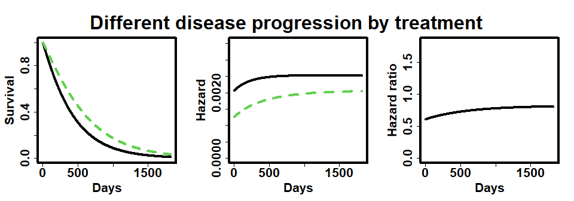

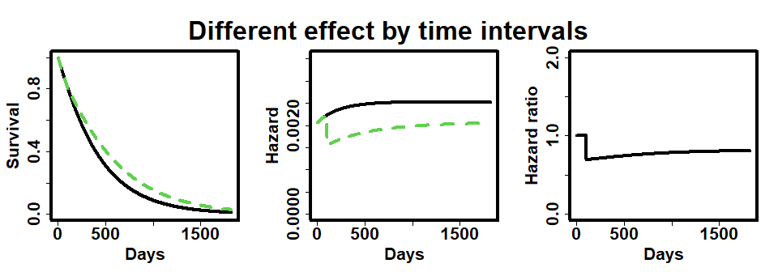

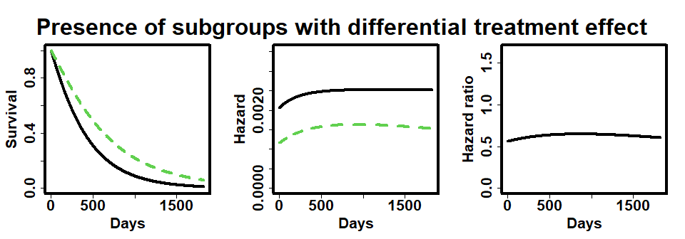

# Basics

The functions of the package can be grouped according to their functionality.

Functions for modelling/setting the underlying survival model:

- `hazVFfun`
- `subpop_pchaz`
- `pop_pchaz`

Functions for generating simulated dataset given for a specified survival model:

- `sample_fun`
- `sample_conditional_fun`

Functions for performing statistical tests:

- `logrank.test`
- `logrank.maxtest`

Plotting functions:

- `plot.mixpch`
- `plot_diagram`
- `plot_shhr`

The basic underlying model for the survival mechanism assumes that each patient can be in one of three states: Alive with no progression of disease, Alive with progression of disease, and Dead.

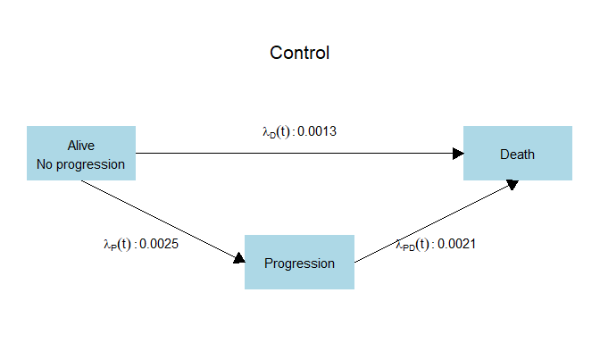

## Creating the population model with pop_pchaz

The hazard rates are assumed piecewise constant functions across $k$ time intervals $[t_{j-1}, t_j)$, $j=1, \ldots,k$ with $0=t_0<t_1<\ldots<t_k=\infty$. Therefore, the `pop_pchaz` function has also an argument `T` that is a vector to specify $t_0,t_1,\ldots,t_k$. When `T` is of length 2 (and therefore only one time interval) `lambdaProgMat`, `lambdaMat1`, and `lambdaMat2` are scalars. If `T` is of length > 2, then the `lambdaProgMat`, `lambdaMat1`, and `lambdaMat2` are matrices where the number of columns is equal to the number of time intervals
$$\begin{bmatrix}\lambda^{[t_0-t_1)} &
\lambda^{[t_1-t_2)} & \ldots
&\lambda^{[t_{k-1}-t_k)}\end{bmatrix}.$$

For example, if the patients are followed for two years but the hazards change after the first year, then `T` should be specified as `c(0, 365, 2*365)`. If we assume a hazard rate for death of 0.02 and 0.04 for the first and second year respectively, the we should specify `lambdaMat1 = matrix(c(0.02, 0.04), ncol = 2)`.

Finally, is is also possible to specify different hazard rates for subgroups. The `pop_pchaz` has the argument `p` which is intended to specify the subgroup prevalences. Given $m$ subgroups with relative sizes $p_1, p_2, \ldots, p_m$, then the `p` argument should be specified as `c(p_1, p_2, ..., p_m)`. The `lambdaProgMat`, `lambdaMat1`, and `lambdaMat2` then should have the number of row equal to the number of defined subgroups:

$$\begin{bmatrix}
\lambda_1 \\
\lambda_2 \\
\ldots \\
\lambda_m
\end{bmatrix}.$$

For example, if patients can be divided into two subgroup with prevalences 0.2 and 0.8 with hazard rates a hazard rate for death of 0.02 and 0.03 thoughout a one year interval, then we define `T = c(0, 365)`, `p = c(0.2, 0.8)` and `lambdaMat1 = matrix(c(0.02, 0.03), nrow = 2)`.

Naturally, it is possible to combine multiple time intervals and subgroups, then the hazard matrices have the form:

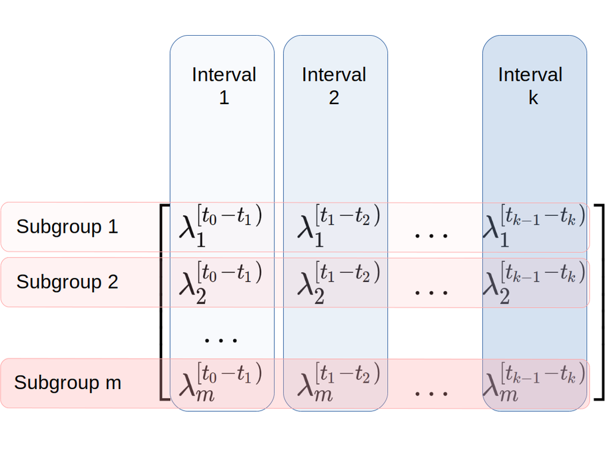

Below, we consider an example where there two subgroups and two time intervals. In practice, this situation correspond to the case where there is a delayed effect of the drug. Note that for specifying the hazard matrices, we use the median time to death/progression and use the function `m2r` (also provided in the package) to obtain the hazard rates.

```r
times <- c(0, 100, 5 * 365)   # Time interval boundaries, in days
t_resp <- c(0.2, 0.8) #Proportion of subgroups
B5 <- pop_pchaz(
  T = times,
  lambdaMat1    = m2r(matrix(c(11, 30,
                               11, 18), byrow = TRUE, nrow = 2)),
  lambdaMat2    = m2r(matrix(c( 9, 20,
                                9, 11), byrow = TRUE, nrow = 2)),
  lambdaProgMat = m2r(matrix(c( 5, 15,
                                5,  9), byrow = TRUE, nrow = 2)),
  p = t_resp, discrete_approximation = TRUE
)
```

The results object is of class `mixpch`, which has a dedicated plotting function to visualize the survival and hazard functions.

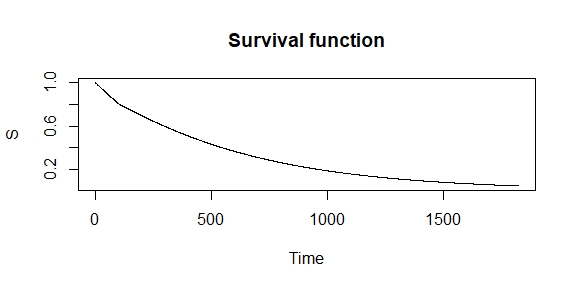

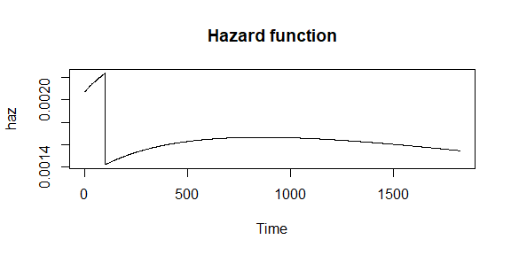

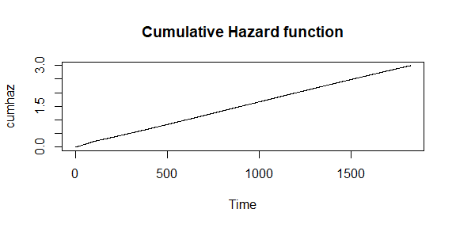

```r
plot(B5, main = "Survival function")
plot(B5, fun = "haz", main = "Hazard function")
plot(B5, fun = "cumhaz", main = "Cumulative Hazard function")
```

## Creating a simulated dataset with sample_fun

The sample_fun function is designed to generate a simulated dataset that would be obtained from a parallel group randomised clinical trial.

The first step is to create two objects with the (theoretical) survival functions for the treatment and control groups using `pop_pchaz`:

```r
times <- c(0, 100, 5 * 365)   # Time interval boundaries, in days
# Treatment group
B5 <- pop_pchaz(T = times,
                   lambdaMat1    = m2r(matrix(c(11, 30,
                                                11, 18), byrow = TRUE, nrow = 2)),
                   lambdaMat2    = m2r(matrix(c( 9, 20,
                                                 9, 11), byrow = TRUE, nrow = 2)),
                   lambdaProgMat = m2r(matrix(c( 5, 15,
                                                 5,  9), byrow = TRUE, nrow = 2)),
                   p = c(0.2, 0.8),#Proportion of subgroups
                discrete_approximation = TRUE
)
# Control group
K5  <- pop_pchaz(T = times,
                    lambdaMat1    = m2r(matrix(c(11, 11), nrow = 1)),
                    lambdaMat2    = m2r(matrix(c( 9,  9), nrow = 1)),
                    lambdaProgMat = m2r(matrix(c( 5,  5), nrow = 1)),
                    p = 1, discrete_approximation = TRUE
)
```

Then, using the resulting objects, we use them to generate a dataset with the `sample_fun` function:

```r
# Study set up and Simulation of a data set until interim analysis at 150 events
set.seed(15657)
dat <- sample_fun(K5, B5,
                  r0 = 0.5,                     # Allocation ratio
                  eventEnd = 450,               # maximal number of events
                  lambdaRecr = 300 / 365,       # recruitment rate per day (Poisson assumption)
                  lambdaCens = 0.013 / 365,     # censoring rate per day  (Exponential assumption)
                  maxRecrCalendarTime = 3 * 365,# Maximal duration of recruitment
                  maxCalendar = 4 * 365.25)     # Maximal study duration
head(dat)
```

```
#>     group inclusion  y yCalendar event adminCens cumEvents
#> 777     1        26  3        29  TRUE     FALSE         1
#> 17      1        25 18        43  TRUE     FALSE         2
#> 367     1         9 40        49  TRUE     FALSE         3
#> 64      0        42  9        51  TRUE     FALSE         4
#> 25      0        34 40        74  TRUE     FALSE         5
#> 708     1       103  7       110  TRUE     FALSE         6
```

```r
tail(dat)
```

```
#>     group inclusion   y yCalendar event adminCens cumEvents
#> 889     1       755 207       962 FALSE      TRUE       450
#> 893     0       205 757       962 FALSE      TRUE       450
#> 896     0       814 148       962 FALSE      TRUE       450
#> 900     1       510 452       962 FALSE      TRUE       450
#> 907     1       225 737       962 FALSE      TRUE       450
#> 908     0       717 245       962 FALSE      TRUE       450
```

## The weighted log-rank test and the max-LRtest

The weighted log-rank test is implemented using the function `logrank.test`, which uses the statistic:

$$z = \sum_{t\in\mathcal{D}} w(t)(d_{t, ctr} - e_{t,ctr}) /
\sqrt{\sum_{t\in\mathcal{D}} w(t)^2 var(d_{t, ctr})}.$$

where $w(t)$ are the Fleming-Harrington $\rho-\gamma$ family weights, such that $w(t)=\widehat{S}(t)^{\rho}(1-\widehat{S}(t))^{\gamma}$. Under the the least favorable configuration in $H_0$, the test statistic is asymptotically standard normally distributed and large values of $z$ are in favor of the alternative.

For example, the following code performs the weighted log-rank test using the simulated dataset and $\rho = 1$ and $\gamma = 0$.

```r
logrank.test(time  = dat$y,
             event = dat$event,
             group = dat$group,
             # alternative = "greater",
             rho   = 1,
             gamma = 0)
```

```
#> Call:
#> logrank.test(time = dat$y, event = dat$event, group = dat$group,
#>     rho = 1, gamma = 0)
#>
#>     N Observed Expected (O-E)^2/E (O-E)^2/V
#> 1 411      267      211      15.2      57.8
#> 2 385      183      239      13.3      57.8
#>
#>  Chisq= 22.1  on 1 degrees of freedom, p= 3e-06
#>  rho   =  1 gamma =  0
```

```r
# survival::survdiff(formula = survival::Surv(time  = dat$y, event = dat$event) ~ dat$group)
```

For a set of $k$ different weight functions $w_1(t), \ldots, w_k(t)$, the maximum log-rank test statistic is $z_{max} = \max_{i=1,\ldots,k}z_i$. Under the least favorable configuration in $H_0$, approximately $(Z_1, \ldots, Z_k) \sim N_k(0, \Sigma)$. The $p$-value of the maximum test, $P_{H_0}(Z_{max} > z_{max})$, is calculated based on this multivariate normal approximation via numeric integration.

The following code performs the maximum log-rank test using four combinations of $\rho$ and $\gamma$ for the weights.

```r
lrmt = logrank.maxtest(
      time  = dat$y,
      event = dat$event,
      group = dat$group,
      rho   = c(0, 0, 1, 1),
      gamma = c(0, 1, 0, 1)
)
lrmt
```

```
#> Call:
#> logrank.maxtest(time = dat$y, event = dat$event, group = dat$group,
#>     rho = c(0, 0, 1, 1), gamma = c(0, 1, 0, 1))
#>
#>  Two sided p-value = 5.09e-08 (Bonferroni corrected: 2.03e-07)
#>
#>  Individual weighted log-rank tests:
#>   Test    z        p
#> 1    1 5.37 7.99e-08
#> 2    2 5.23 1.73e-07
#> 3    3 4.70 2.63e-06
#> 4    4 5.45 5.08e-08
```

```r
lrmt$logrank.test[[1]]
```

```
#> Call:
#> logrank.test(time = time, event = event, group = group, alternative = alternative,
#>     rho = rho[i], gamma = gamma[i])
#>
#>     N Observed Expected (O-E)^2/E (O-E)^2/V
#> 1 411      267      211      15.2      28.8
#> 2 385      183      239      13.3      28.8
#>
#>  Chisq= 28.8  on 1 degrees of freedom, p= 8e-08
#>  rho   =  0 gamma =  0
```

```r
lrmt$logrank.test[[2]]
```

```
#> Call:
#> logrank.test(time = time, event = event, group = group, alternative = alternative,
#>     rho = rho[i], gamma = gamma[i])
#>
#>     N Observed Expected (O-E)^2/E (O-E)^2/V
#> 1 411      267      211      15.2       187
#> 2 385      183      239      13.3       187
#>
#>  Chisq= 27.3  on 1 degrees of freedom, p= 2e-07
#>  rho   =  0 gamma =  1
```

```r
lrmt$logrank.test[[3]]
```

```
#> Call:
#> logrank.test(time = time, event = event, group = group, alternative = alternative,
#>     rho = rho[i], gamma = gamma[i])
#>
#>     N Observed Expected (O-E)^2/E (O-E)^2/V
#> 1 411      267      211      15.2      57.8
#> 2 385      183      239      13.3      57.8
#>
#>  Chisq= 22.1  on 1 degrees of freedom, p= 3e-06
#>  rho   =  1 gamma =  0
```

```r
lrmt$logrank.test[[4]]
```

```
#> Call:
#> logrank.test(time = time, event = event, group = group, alternative = alternative,
#>     rho = rho[i], gamma = gamma[i])
#>
#>     N Observed Expected (O-E)^2/E (O-E)^2/V
#> 1 411      267      211      15.2       810
#> 2 385      183      239      13.3       810
#>
#>  Chisq= 29.7  on 1 degrees of freedom, p= 5e-08
#>  rho   =  1 gamma =  1
```